# Topicmodeling: Illustrative example: Abstracts of JSS papers

Get Data

```r
#install.packages("corpus.JSS.papers", repos = "http://datacube.wu.ac.at/", type = "source")
data("JSS_papers", package = "corpus.JSS.papers")
```

For reproducibility of results we use only abstracts published up to 2010-08-05 and omit those containing non-ASCII characters in the abstracts.

```r
JSS_papers <- JSS_papers[JSS_papers[,"date"] < "2010-08-05",];dim(JSS_papers)
```

```
## [1] 361  15
```

```r
JSS_papers <- JSS_papers[sapply(JSS_papers[, "description"],Encoding) == "unknown",];dim(JSS_papers)
```

```
## [1] 348  15
```

```r
dim(JSS_papers)
```

```
## [1] 348  15
```

```r
prod(dim(JSS_papers))
```

```
## [1] 5220
```

tm –

The final data set contains 348 documents. Before analysis we transform it to a “Corpus” using package tm. HTML markup in the abstracts for greek letters, subscripting, etc., is removed using package XML

```r
#install.packages('tm', dep=T)
#install.packages('XML', dep=T)
library("tm")
library("XML")
```

```r
remove_HTML_markup <- function(s) tryCatch({
 doc <- htmlTreeParse(paste("<!DOCTYPE html>", s), asText = TRUE, trim = FALSE)
 xmlValue(xmlRoot(doc))
 }, error = function(s) s)
```

```r
?Corpus
?VectorSource
```

```r
JSS_papers[, "description"][1]
```

```
## [[1]]
## [1] "The fit of a variogram model to spatially-distributed data is often difficult to assess. A graphical diagnostic written in S-plus is introduced that allows the user to determine both the general quality of the fit of a variogram model, and to find specific pairs of locations that do not have…
```

```r
sapply(JSS_papers[, "description"][1],remove_HTML_markup)
```

```
## [1] "The fit of a variogram model to spatially-distributed data is often difficult to assess. A graphical diagnostic written in S-plus is introduced that allows the user to determine both the general quality of the fit of a variogram model, and to find specific pairs of locations that do not have…
```

```r
VectorSource(sapply(JSS_papers[, "description"][1],remove_HTML_markup))
```

```
## $encoding
## [1] ""
##
## $length
## [1] 1
##
## $position
## [1] 0
##
## $reader
## function (elem, language, id)
## {
##     if (!is.null(elem$uri))
##         id <- basename(elem$uri)
##     PlainTextDocument(elem$content, id = id, language = language)
## }
## <environment: namespace:tm>
##
## $content
## [1] "The fit of a variogram model to spatially-distributed data is often difficult to assess. A graphical diagnostic written in S-plus is introduced that allows the user to determine both the general quality of the fit of a variogram model, and to find specific pairs of locations that do not have…
##
## attr(,"class")
## [1] "VectorSource" "SimpleSource" "Source"
```

```r
c  <- Corpus(VectorSource(sapply(JSS_papers[, "description"][1],remove_HTML_markup)));c
```

```
## <<VCorpus (documents: 1, metadata (corpus/indexed): 0/0)>>
```

```r
corpus <- Corpus(VectorSource(sapply(JSS_papers[, "description"],
                                     remove_HTML_markup)));corpus
```

```
## <<VCorpus (documents: 348, metadata (corpus/indexed): 0/0)>>
```

```r
class(corpus)
```

```
## [1] "VCorpus" "Corpus"
```

```r
mode(corpus)
```

```
## [1] "list"
```

The corpus is exported to a document-term matrix using function DocumentTermMatrix() from package tm. The terms are stemmed and the stop words, punctuation, numbers and terms of length less than 3 are removed using the control argument. (We use a C locale for reproducibility.)

```r
Sys.setlocale("LC_COLLATE", "C")
```

```
## [1] "C"
```

```r
JSS_dtm <- DocumentTermMatrix(corpus,
 control = list(stemming = TRUE, stopwords = TRUE, minWordLength = 3,
 removeNumbers = TRUE, removePunctuation = TRUE))
```

```r
str(JSS_dtm)
```

```
## List of 6
##  $ i       : int [1:19509] 1 1 1 1 1 1 1 1 1 1 ...
##  $ j       : int [1:19509] 103 231 472 696 739 872 961 980 981 1001 ...
##  $ v       : num [1:19509] 1 1 1 1 1 3 1 1 1 1 ...
##  $ nrow    : int 348
##  $ ncol    : int 4289
##  $ dimnames:List of 2
##   ..$ Docs : chr [1:348] "1" "2" "3" "4" ...
##   ..$ Terms: chr [1:4289] "abc" "abil" "abl" "abov" ...
##  - attr(*, "class")= chr [1:2] "DocumentTermMatrix" "simple_triplet_matrix"
##  - attr(*, "weighting")= chr [1:2] "term frequency" "tf"
```

```r
names(JSS_dtm)
```

```
## [1] "i"        "j"        "v"        "nrow"     "ncol"     "dimnames"
```

```r
class(JSS_dtm)
```

```
## [1] "DocumentTermMatrix"    "simple_triplet_matrix"
```

```r
mode(JSS_dtm)
```

```
## [1] "list"
```

Document term Martix

```r
JSS_dtm # all documents & All (4289) terms
```

```
## <<DocumentTermMatrix (documents: 348, terms: 4289)>>
## Non-/sparse entries: 19509/1473063
## Sparsity           : 99%
## Maximal term length: 36
## Weighting          : term frequency (tf)
```

```r
JSS_dtm[1,] # 1st Document and all (4289) terms
```

```
## <<DocumentTermMatrix (documents: 1, terms: 4289)>>
## Non-/sparse entries: 38/4251
## Sparsity           : 99%
## Maximal term length: 36
## Weighting          : term frequency (tf)
```

```r
JSS_dtm[,1] # All documents and First term
```

```
## <<DocumentTermMatrix (documents: 348, terms: 1)>>
## Non-/sparse entries: 1/347
## Sparsity           : 100%
## Maximal term length: 3
## Weighting          : term frequency (tf)
```

```r
JSS_dtm$nrow; #348
```

```
## [1] 348
```

```r
JSS_dtm$ncol # 4289
```

```
## [1] 4289
```

```r
length(JSS_dtm$i) # 19509
```

```
## [1] 19509
```

```r
length(JSS_dtm$j) # 19509
```

```
## [1] 19509
```

```r
length(JSS_dtm$v) # 19609
```

```
## [1] 19509
```

Document

```r
range(JSS_dtm$i)  # 1 - 348
```

```
## [1]   1 348
```

Term

```r
range(JSS_dtm$j)  # 1 - 4289
```

```
## [1]    1 4289
```

Frequency

```r
range(JSS_dtm$v)  # 1 - 14
```

```
## [1]  1 14
```

[output not shown]

[output not shown]

Number of terms whose frequency is 1

```r
sum(JSS_dtm$v == 1)
```

```
## [1] 15719
```

Number of terms with frequency 13

```r
sum(JSS_dtm$v == 13)
```

```
## [1] 1
```

Number of terms with frequency 14

```r
sum(JSS_dtm$v == 14)
```

```
## [1] 1
```

plot of frequencies

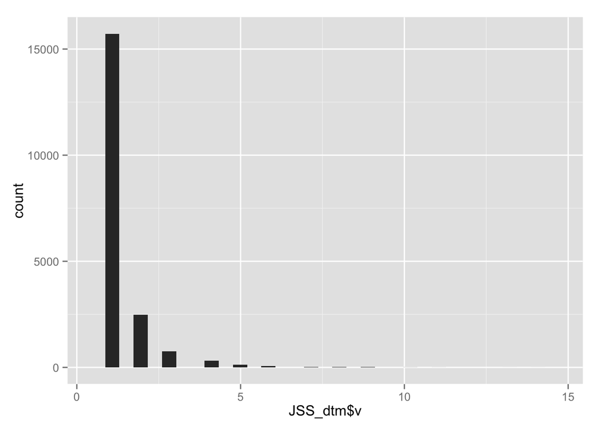

```r
#install.packages('ggplot2',dep=T)
library(ggplot2)
qplot(JSS_dtm$v)
```

slam: Sparse Lightweight Arrays and Matrices

Data structures and algorithms for sparse arrays and matrices, based on index arrays and simple triplet representations, respectively.

Load Slam package

```r
library("slam")
```

`col_sums`: Form row and column sums and means for sparse arrays (currently `simple_triplet_matrix` only).

```r
?col_sums
```

rows is the documents columns are the terms

Gives terms and their frequencies

```r
JSS_dtm$ncol #4289
```

```
## [1] 4289
```

```r
length(col_sums(JSS_dtm)) #4289
```

```
## [1] 4289
```

```r
length(JSS_dtm$j) #19509
```

```
## [1] 19509
```

```r
length(JSS_dtm$v) #19509
```

```
## [1] 19509
```

```r
JSS_dtm$nrow #348
```

```
## [1] 348
```

```r
JSS_dtm
```

```
## <<DocumentTermMatrix (documents: 348, terms: 4289)>>
## Non-/sparse entries: 19509/1473063
## Sparsity           : 99%
## Maximal term length: 36
## Weighting          : term frequency (tf)
```

```r
head(col_sums(JSS_dtm))
```

```
##     abc    abil     abl    abov  absenc absolut
##       1      10      10       2       1       4
```

```r
str(col_sums(JSS_dtm))
```

```
##  Named num [1:4289] 1 10 10 2 1 4 1 2 1 4 ...
##  - attr(*, "names")= chr [1:4289] "abc" "abil" "abl" "abov" ...
```

```r
class(col_sums(JSS_dtm))
```

```
## [1] "numeric"
```

Distribution of term frequencies - Skewed

```r
summary(col_sums(JSS_dtm))
```

```
##    Min. 1st Qu.  Median    Mean 3rd Qu.    Max.
##    1.00    1.00    2.00    5.98    4.00  450.00
```

```r
#qplot(col_sums(JSS_dtm))
```

The mean term frequency-inverse document frequency (tf-idf) over documents containing this term is used to select the vocabulary. This measure allows to omit terms which have low frequency as well as those occurring in many documents. We only include terms which have a tf-idf value of at least 0.1 which is a bit more than the median and ensures that the very frequent terms are omitted.

```r
term_tfidf <-
 tapply(JSS_dtm$v/row_sums(JSS_dtm)[JSS_dtm$i],
        JSS_dtm$j, mean) * log2(nDocs(JSS_dtm)/col_sums(JSS_dtm > 0))
```

```r
?tapply
```

```r
str(term_tfidf)
```

```
##  num [1:4289(1d)] 0.1624 0.0612 0.0779 0.0815 0.0534 ...
##  - attr(*, "dimnames")=List of 1
##   ..$ : chr [1:4289] "1" "2" "3" "4" ...
```

```r
length(term_tfidf)  # 4289
```

```
## [1] 4289
```

```r
class(term_tfidf)
```

```
## [1] "array"
```

```r
#attributes(term_tfidf)
head(term_tfidf)
```

```
##          1          2          3          4          5          6
## 0.16236430 0.06123303 0.07785028 0.08145538 0.05343635 0.09591643
```

Distribution - Slightly less skewed

```r
summary(term_tfidf)
```

```
##    Min. 1st Qu.  Median    Mean 3rd Qu.    Max.
## 0.01520 0.07472 0.09817 0.12210 0.13840 1.16500
```

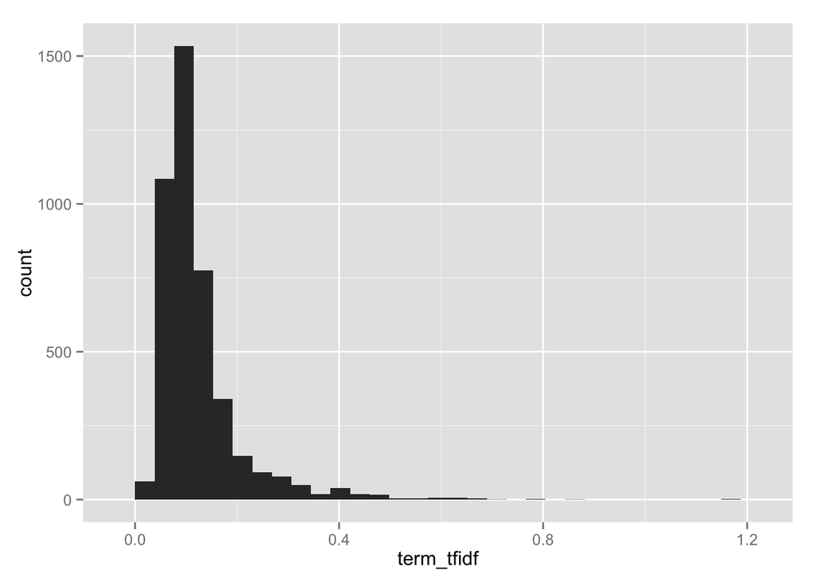

```r
qplot(term_tfidf)
```

```r
dim(JSS_dtm)  # 348 4289
```

```
## [1]  348 4289
```

```r
length(term_tfidf)  # 4289
```

```
## [1] 4289
```

```r
sum(term_tfidf >= 0.1) # 2086
```

```
## [1] 2086
```

```r
JSS_dtm <- JSS_dtm[,term_tfidf >= 0.1];
JSS_dtm$nrow
```

```
## [1] 348
```

```r
JSS_dtm <- JSS_dtm[row_sums(JSS_dtm) > 0,]
JSS_dtm$nrow
```

```
## [1] 348
```

```r
summary(col_sums(JSS_dtm))
```

```
##    Min. 1st Qu.  Median    Mean 3rd Qu.    Max.
##   1.000   1.000   1.000   2.763   3.000  47.000
```

```r
JSS_dtm
```

```
## <<DocumentTermMatrix (documents: 348, terms: 2086)>>
## Non-/sparse entries: 3895/722033
## Sparsity           : 99%
## Maximal term length: 36
## Weighting          : term frequency (tf)
```

```r
summary(col_sums(JSS_dtm))  # 1 - 47
```

```
##    Min. 1st Qu.  Median    Mean 3rd Qu.    Max.
##   1.000   1.000   1.000   2.763   3.000  47.000
```

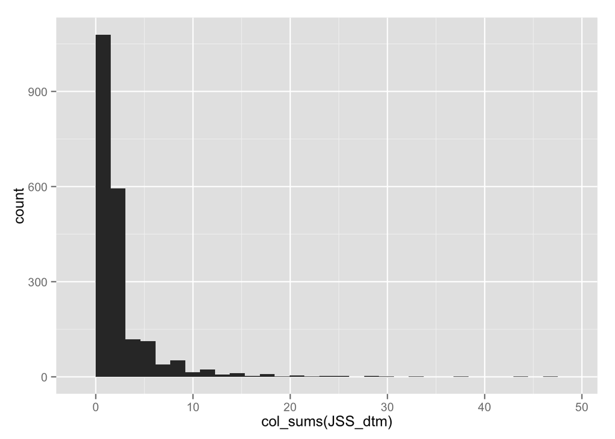

```r
qplot(col_sums(JSS_dtm))
```

```r
#install.packages('topicmodels',dep=T)
library("topicmodels")
```